# ACMT Setup Instructions

### 1. Install the Docker

**If you are not the admin on your computer, you must have IT install Docker and add you to the docker-user group**

*Adding non-admin users to the Docker User group*

1. Run Computer Management as an administrator
2. Navigate to Local Users and Groups > Groups > docker-users
3. Right-click to add the user to the group
4. Sign out and sign back in for the changes to take effect.

**If you have administrative privileges, you can download and install Docker yourself:**

- Download and install the Docker
- Go to https://www.docker.com/
- Click on the “Get Started” button in the top right corner
- Click on the Download button that works for your computer – if you have a Macbook with an apple chip, select apple chip.
- Once the download completes, follow the instructions to complete installation.

**NOTE: if you do not have administrator privileges, you will need your IT to download and install Docker for you and make you a user in the Docker-user group so that you can run Docker as an admin. [See here for more instructions](https://docs.docker.com/desktop/install/windows-install/#install-docker-desktop-on-windows)

#### 1(b) **For mac (M1 or M2 chip)**

- navigate to the Docker Settings. Check the box for ‘Use Rosetta for x86/amd64 emulation on Apple Silicon’ under General.
- you may find you need to run $ softwareupdate –install-rosetta in your terminal

[figure not shown]

Docker Settings: check the Use Docker Compose V2 option

#### 1(c) **For windows**

- You will need to Download the WSL 2 Linux kernel Windows update
- Go to https://docs.microsoft.com/en-us/windows/wsl/install-manual#step-4---download-the-linux-kernel-update-package
- Click the link to download the WSL2 Linux kernel update package
- The update will download, follow the steps to finalize the update

### 2. Download the ACMT Source code

- Go to https://github.com/2533245542/acmt-network
  - Click on the green ‘Code’ button, then select Download ZIP.
    - Unzip the ACMT Code to the documents folder on your computer (i.e., C:) and **rename the folder to acmt-network**.

[figure not shown]

Download ACMT source code from github

### 3. Edit the .env file to include specific states

- In the ‘acmt-network’ folder, find the file named .env (If you do not see the file named .env on MacOS, you may need to press “command + shift + .” to make finder show you hidden files) and open it in Notepad.
  - Edit the GEOCODER_STATES line to include any state that you would like included:
  - i.e., GEOCODER_STATES=WA, MN, TX
  - WA does not need to be included, but if you do not include it, you may need to enter an address from your study instead in the testing section below
  - To include all states, put GEOCODER_STATES=* (note that the more state you include the longer the ACMT will take to install)
  - Save and close the file

### 4. Install the ACMT

- Open Command Prompts (PC) or Terminal (Mac)
  - In Windows: https://www.howtogeek.com/235101/10-ways-to-open-the-command-prompt-in-windows-10/
  - On a Mac: https://www.howtogeek.com/682770/how-to-open-the-terminal-on-a-mac/
- Navigate to the acmt-network folder in the terminal
  - Type cd then the folder path, see examples below
  - You can also check the contents of the folder by typing ‘ls’ or ‘dir’, for example to ensure you are in the right folder.
- Finally, you can install the ACMT by running docker-compose up –build in the terminal (assure you have two dashes in front of build)
- This process can take 30 minutes or longer (depending on how many states you selected to load in). Expect an additional 30 minutes or so for each additional state (the actual length depends on your download speeds)
- Examples of code:

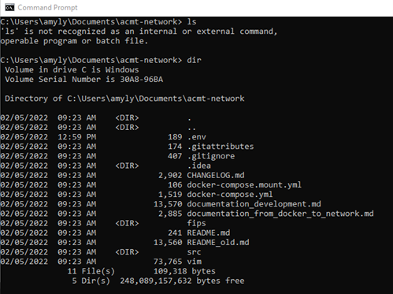

Show the contents of the folder in the terminal/command prompt window

[figure not shown]

Navigate to the folder path in the terminal/command prompt window

### 5. Set up the ACMT

[figure not shown]

Start the acmt-network container in the Docker (play button)

- Navigate to http://localhost:8787/ in a web browser. You should see a Rstudio workspace in your browser:

[figure not shown]

Navigate to the ACMT url in your browswer to open a Rstudio environment

- Note that while you’re running R in a browser, it is running in your own local environment. When you close the window and stop the container in the Docker, your data will be retained. However, if you upgrade your Docker or delete Docker, your Rstudio environment and all the files will be lost, so you will want to download and save the data from your Rstudio files locally before removing Docker at the end of the data pulling process.

### 6. Test the ACMT Geocoder

- To test the geocoder function and ensure the state data has successfully been loaded into the Docker database, first open the TestDockerACMT.R file.
- Run the first few lines of code to create the geocoder() functions and geocode() the UW address.
- *Note if you did not load WA state, or if there are other states that have been loaded and need to be tested, update the address listed in the geocode function*

### 7. Run the Shiny Application in R

- The complete code and instructions for geocoding and pulling environmental data for your dataset are in the file named, ‘ACMT_shiny/ACMT Shiny App.R’. Open this app, then click the ‘Run App’ button in the top right corner of the page of code:

[figure not shown]

Run the Inspace application

- Instructions for each step of the geocoding and data pull process are laid out in the Shiny app.
- If you run into any issues or have additional questions, reach out to Amy at aybloom@uw.edu.

### 7. Pausing and restarting the ACMT

- Pausing the ACMT saves your work in the Rstudio environment. However, because periodic updates to the Docker may result in a loss of Rstudio environment files, a good practice is to download and save your files locally on a regular basis (your data pull files are all located in the ‘data_pull_measures’ folder in your Inspace folder in Rstudio). You can select the entire data_pull_measures folder, then click “More” (with the gear icon) and select export to download your folder.
- To pause the ACMT, save any work, then close the browser tab.
  - Next navigate to the Docker application and click the ‘STOP’ button for the acmt-network container
- When you are ready to resume, reopen the Docker and press the start button for the acmt-network container (may take a few seconds to start).
  - Once the container is started, go to http://localhost:8787/ in your web browser.